# ecommerce_reg_2113오지원

## 선형 회귀

- 캐글 전자상거래 데이터 사용 https://www.kaggle.com/srolka/ecommerce-customers
- 캐글에서 데이터의 속성 확인하기
- Yearly Amount Spent(연간 소비 지출액)에 영향을 미치는 속성이 무엇인지 알아보고 핵심속성을 사용하여 구한 추세선을 바탕으로 연간 소비 지출액을 예측해보자
1. 라이브러리 불러오기 및 데이터 업로드

```python
# 파일 가져오기 : 아래 1,2 방법 중 하나를 골라 사용하세요.

# 파일 가져오기1 (내 컴퓨터에서 직접 업로드)
from google.colab import files
uploaded = files.upload()
```

```python
from google.colab import drive
drive.mount('/content/drive')
```

```python
path='/content/drive/MyDrive/Colab Notebooks/Ecommerce Customers.csv'
```

```python
import pandas as pd
import numpy as np
import seaborn as sns
import matplotlib.pyplot as plt

# 데이터 불러오기 및 확인
dataset=pd.read_csv(path)
dataset.head() #위에 5행 출력
```

|  | Email | Address | Avatar | Avg. Session Length | Time on App | Time on Website | Length of Membership | Yearly Amount Spent |
| --- | --- | --- | --- | --- | --- | --- | --- | --- |
| 0 | mstephenson@fernandez.com | 835 Frank Tunnel\nWrightmouth, MI 82180-9605 | Violet | 34.497268 | 12.655651 | 39.577668 | 4.082621 | 587.951054 |
| 1 | hduke@hotmail.com | 4547 Archer Common\nDiazchester, CA 06566-8576 | DarkGreen | 31.926272 | 11.109461 | 37.268959 | 2.664034 | 392.204933 |
| 2 | pallen@yahoo.com | 24645 Valerie Unions Suite 582\nCobbborough, D... | Bisque | 33.000915 | 11.330278 | 37.110597 | 4.104543 | 487.547505 |
| 3 | riverarebecca@gmail.com | 1414 David Throughway\nPort Jason, OH 22070-1220 | SaddleBrown | 34.305557 | 13.717514 | 36.721283 | 3.120179 | 581.852344 |
| 4 | mstephens@davidson-herman.com | 14023 Rodriguez Passage\nPort Jacobville, PR 3... | MediumAquaMarine | 33.330673 | 12.795189 | 37.536653 | 4.446308 | 599.406092 |

```python
# 데이터셋의 기본 정보
dataset.info()

#500 entries : 500개의 데이터
#Non null Count : 여기선 다 500이므로 전처리 해줘야할 데이터가 없다
```

```
<class 'pandas.core.frame.DataFrame'>
RangeIndex: 500 entries, 0 to 499
Data columns (total 8 columns):
 #   Column                Non-Null Count  Dtype
---  ------                --------------  -----
 0   Email                 500 non-null    object
 1   Address               500 non-null    object
 2   Avatar                500 non-null    object
 3   Avg. Session Length   500 non-null    float64
 4   Time on App           500 non-null    float64
 5   Time on Website       500 non-null    float64
 6   Length of Membership  500 non-null    float64
 7   Yearly Amount Spent   500 non-null    float64
dtypes: float64(5), object(3)
memory usage: 31.4+ KB
```

```python
# 데이터셋의 통계 정보
dataset.describe()
```

|  | Avg. Session Length | Time on App | Time on Website | Length of Membership | Yearly Amount Spent |
| --- | --- | --- | --- | --- | --- |
| count | 500.000000 | 500.000000 | 500.000000 | 500.000000 | 500.000000 |
| mean | 33.053194 | 12.052488 | 37.060445 | 3.533462 | 499.314038 |
| std | 0.992563 | 0.994216 | 1.010489 | 0.999278 | 79.314782 |
| min | 29.532429 | 8.508152 | 33.913847 | 0.269901 | 256.670582 |
| 25% | 32.341822 | 11.388153 | 36.349257 | 2.930450 | 445.038277 |
| 50% | 33.082008 | 11.983231 | 37.069367 | 3.533975 | 498.887875 |
| 75% | 33.711985 | 12.753850 | 37.716432 | 4.126502 | 549.313828 |
| max | 36.139662 | 15.126994 | 40.005182 | 6.922689 | 765.518462 |

1. 시각화하기
- 앱을 사용한 시간과 웹을 사용한 시간에 따라 어떠한 영향을 미치는지 산점도로 시각화해보자.
- 특정 속성 간의 산점도를 출력하여 상관관계를 알아보자
- jointplot

> 두 개의 수치형 변수 간의 관계 확인, 차트의 중앙에는 상관관계 그래프를 그려주고, 상단과 오른쪽은 히스토그램을 사용하여 두 변수의 분포를 보여줌

> 중앙 그래프는 기본이 산점도. 변경은 kind='reg' 등으로 변경

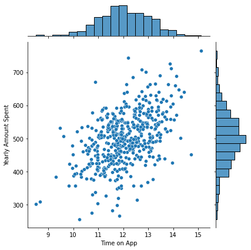

```python
# 앱 사용시간과 연간 소비 지출액 간의 산점도 출력
sns.jointplot(x = "Time on App", y = "Yearly Amount Spent", data=dataset)

#알 수있는 사실
#12시간, 500달러 중앙인 값들의 수치가 높다.
#대략적으로 앱에 머무르는 시간이 길수록 돈을 많이 사용한다.
```

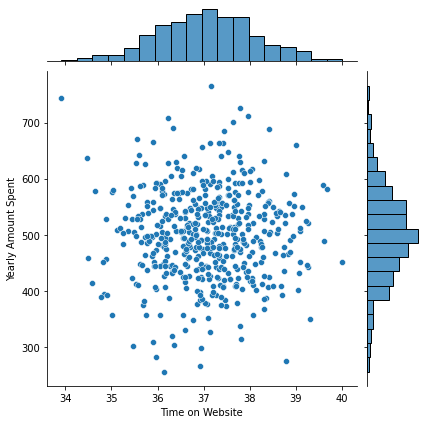

```python
# 웹 사용시간과 연간 소비 지출액 간의 산점도 출력
sns.jointplot(x = "Time on Website" , y = "Yearly Amount Spent", data=dataset)

#상관관계가 잘 보이지 않는다.
```

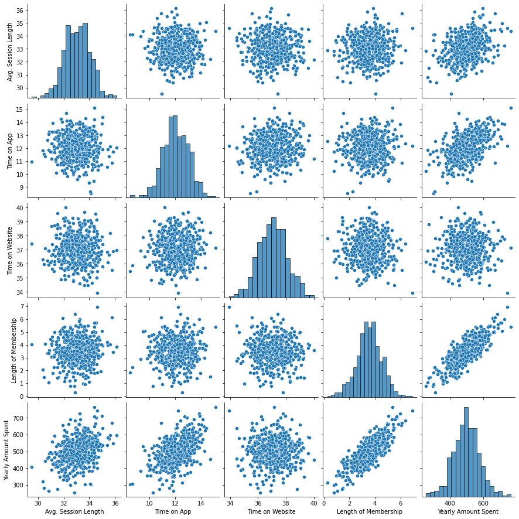

```python
# 모든 속성 간의 산점도 출력
sns.pairplot(dataset)

#같은 데이터끼리의 관계는 산점도로 나타내는게 의미가 없기 때문에 히스토그램으로 나타냄
#Length od Membership과 Yearly Amount Spent 사이에 선형적인 관계가 있다는 것을 분석할 수 있으면 된다.
```

```python
# 특정 속성 간의 상관 계수 출력
dataset.corr()

#0에 가까울수록 전혀 관련이 없다.
#1에 가까울수록 우상향적인 관련이 있다.
#같은데이터끼리는 당연히 1이고, Length of Membership과 Yearly Amount Spent와 0.809..로 상관관계가 크다.
```

|  | Avg. Session Length | Time on App | Time on Website | Length of Membership | Yearly Amount Spent |
| --- | --- | --- | --- | --- | --- |
| Avg. Session Length | 1.000000 | -0.027826 | -0.034987 | 0.060247 | 0.355088 |
| Time on App | -0.027826 | 1.000000 | 0.082388 | 0.029143 | 0.499328 |
| Time on Website | -0.034987 | 0.082388 | 1.000000 | -0.047582 | -0.002641 |
| Length of Membership | 0.060247 | 0.029143 | -0.047582 | 1.000000 | 0.809084 |
| Yearly Amount Spent | 0.355088 | 0.499328 | -0.002641 | 0.809084 | 1.000000 |

1. 산점도 표현과 추세선 그리기

```python
# 핵심 속성 선택하기
select_columns = dataset[['Time on App','Length of Membership','Yearly Amount Spent']] #세가지 데이터만 따로 잘라와서 머신러닝을 실행시키겠다.
```

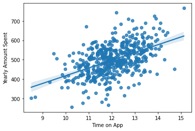

```python
# 앱 사용 시간에 따른 연간 소비 지출액 산점도와 추세선 출력하기
sns.regplot(x = 'Time on App',y = 'Yearly Amount Spent',data= select_columns)

#regplot : 회귀,산점도와 추세선을 그려줌
```

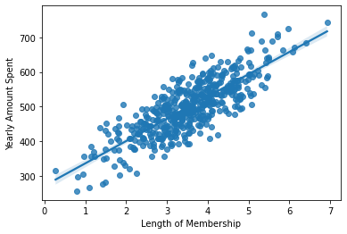

```python
# 멤버십 기간에 따른 연간 소비 지출액 산점도와 추세선 출력하기
sns.regplot(x = "Length of Membership", y = "Yearly Amount Spent", data= select_columns)
```

1. 머신러닝을 활용한 선형회귀
- 가장 상관관계가 높은 멤버십 기간 속성을 가지고 머신러닝 모델에 학습시키고 연간 소비 지출액을 예측하고 검증해보자
- https://scikit-learn.org/stable/

# 맴버쉽 기간으로 학습하기

```python
# 훈련 데이터와 테스트 데이터를 7:3으로 분할하기

# X는 독립변수 : 멤버십 사용시간
# y는 종속변수 : 연간 소비 지출액

X= select_columns[["Length of Membership"]]
y= select_columns["Yearly Amount Spent"]

from sklearn.model_selection import train_test_split

X_train, X_test, y_train, y_test = train_test_split(X, y, test_size=0.3, random_state=10)

#주로 윗줄과 같은 구성으로 데이터를 지정함 (X훈련,X테스트,y훈련,y테스트)

#X_train, X_test, y_train, y_test = train_test_split : 위에서 X,y로 지정한 데이터를 이용하여 나눠줘!
#test_size : 어떻게 나눌래? (0.3이면 7:3으로, 0.2이면 8:2로)
#random_state : 어떤 방법으로 섞을래? (하나의 데이터에 대해서 다룰때는 같은 random_state(숫자)로 섞자 )
```

```python
# 학습 후 추세선의 기울기와 y절편 구하기

from sklearn.linear_model import LinearRegression

model = LinearRegression()
model.fit(X_train, y_train) #학습해라
print('추세선의 기울기 : ', model.coef_)
print('추세선의 y절편 : ', model.intercept_)
```

```
추세선의 기울기 :  [62.11156805]
추세선의 y절편 :  277.8361258708966
```

```python
#정확도 확인하기
r_score = model.score(X_test,y_test)
print('정확도 : ',r_score)
```

```
정확도 :  0.6842293668412762
```

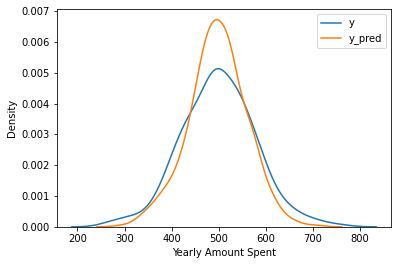

```python
# 모델의 예측 결과(y_pred)와 실제 값(y) 비교하기
# sns.distplot = 분포그래프 = 히스토그램

y_pred=model.predict(X)

sns.distplot(y, hist=False,  label='y') #hist=False : 히스토그램 막대없이
sns.distplot(y_pred, hist=False, label='y_pred')

plt.legend()
plt.show()
```

1. 새로운 값으로 모델 예측하기

```python
X1=[[6.5],[7],[7.5]] #맴버쉽 기간
model.predict(X1) #위의 각각의 기간에 대한 값을 예측해봐!
```

```
array([681.5613182 , 712.61710222, 743.67288624])
```

[실습]

1. 앱 사용 시간으로 학습시켜보자.
2. 앱 사용 시간과 멤버십 기간 속성 두 개의 속성으로 학습시키고 모델의 예측 결과와 실제값을 비교해보자.(다중회귀)

# 앱 사용 시간으로 학습하기

```python
# 앱 사용 시간으로 학습하기
X1= select_columns[["Time on App"]]
y1= select_columns["Yearly Amount Spent"]

from sklearn.model_selection import train_test_split

X1_train, X1_test, y1_train, y1_test = train_test_split(X1, y1, test_size=0.3, random_state=10)
```

```python
from sklearn.linear_model import LinearRegression

model1 = LinearRegression()
model1.fit(X1_train, y1_train) #학습해라
print('추세선의 기울기 : ', model1.coef_)
print('추세선의 y절편 : ', model1.intercept_)
r_score1 = model1.score(X1_test,y1_test)
print('정확도 : ',r_score1)
```

```
추세선의 기울기 :  [36.57442076]
추세선의 y절편 :  53.90674016748892
정확도 :  0.2468463532187689
```

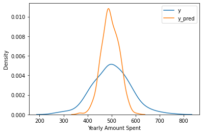

```python
y_pred=model1.predict(X1)

sns.distplot(y1, hist=False,  label='y') #hist=False : 히스토그램 막대없이
sns.distplot(y_pred, hist=False, label='y_pred')

plt.legend()
plt.show()
```

```python
X1 = [[32],[11],[4]]#앱 사용시간으로 예측하기
print(model1.predict(X1))
```

```
[1224.28820438  456.22536849  200.20442319]
```

# 두개의 속성(맴버쉽 기간, 앱사용시간)으로 학습하기

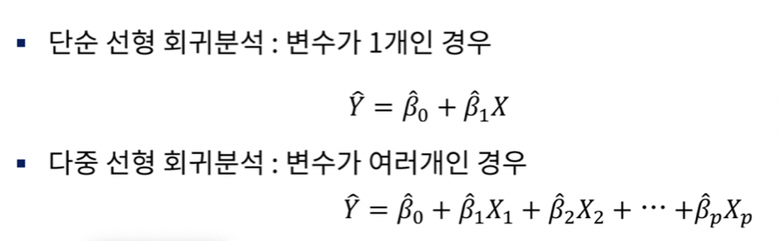

```python
# 두 개의 속성으로 다중회귀하기
X2 = select_columns[['Time on App', 'Length of Membership']] #두개의 속성!!
y2= select_columns["Yearly Amount Spent"]

from sklearn.model_selection import train_test_split

X2_train, X2_test, y2_train, y2_test = train_test_split(X2, y2, test_size=0.3, random_state=10)
```

```python
from sklearn.linear_model import LinearRegression

model2 = LinearRegression()
model2.fit(X2_train, y2_train) #학습해라
print('추세선의 기울기 : ', model2.coef_)
print('추세선의 y절편 : ', model2.intercept_)
r_score = model2.score(X2_test,y2_test)
print('정확도 : ',r_score) #결과를 보니 더 높게 나온다! 관련이 높은 데이터끼리 다중회귀를 하니 정확도가 상승했다!!

#추세선의 기울기 가 두개가 나오는 이유는 뭘까?
#y = w1x1 + w2x2 + w0 꼴이기 때문에 w1과 w2 두가지가 기울기 값으로 출력되었다.
```

```
추세선의 기울기 :  [37.59569322 62.75308288]
추세선의 y절편 :  -176.46448608828734
정확도 :  0.8934157221660259
```

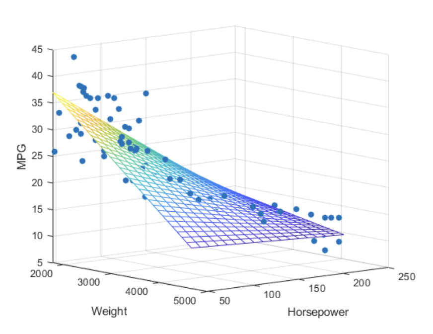

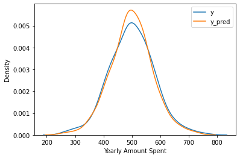

```python
y_pred=model2.predict(X2)

sns.distplot(y2, hist=False,  label='y') #hist=False : 히스토그램 막대없이
sns.distplot(y_pred, hist=False, label='y_pred')

plt.legend()
plt.show()
```

```python
X2 = [[32,3.3],[21,4],[16,3.3]]#앱 사용시간과 맴버쉽기간으로 예측하기
print(model2.predict(X2))
```

```
[1233.68287044  864.05740303  632.15177892]
```

```python
!jupyter nbconvert --to html "/content/drive/MyDrive/Colab Notebooks/ecommerce_reg_2113오지원.ipynb"
```

```
[NbConvertApp] Converting notebook /content/drive/MyDrive/Colab Notebooks/ecommerce_reg_2113오지원.ipynb to html
[NbConvertApp] Writing 1864866 bytes to /content/drive/MyDrive/Colab Notebooks/ecommerce_reg_2113오지원.html
```